# SPY Vol Regime + Momentum Strategy

Dante Peinado

2026-08-05

## Overview

This project implements a systematic long-only strategy on SPY combining two uncorrelated signals: a rolling volatility regime classifier and an EMA momentum filter. The strategy was developed in R using tidyquant and validated with a train/test split across 15 years of data (2010-2024).

The vol regime classifier architecture was inspired by dynamic threshold monitoring work done during an actuarial internship at Chubb Insurance, where I developed a sliding time-window percentile threshold for seasonal claims analysis. The same methodology is applied here to classify market environments.

```r
library(tidyverse)
library(quantmod)
library(tidyquant)
library(TTR)

getSymbols("SPY", from = "2010-01-01", to = "2024-12-31")
```

```
## [1] "SPY"
```

## Data & Signal Construction

### Price Data & Momentum Signals

```r
spy_prices <- data.frame(
  date = index(SPY),
  SPY.Adjusted = coredata(Ad(SPY))
) |>
  mutate(
    ema_fast = EMA(SPY.Adjusted, n=10),
    ema_slow = EMA(SPY.Adjusted, n=30)
  )
```

### Rolling Volatility & Regime Classification

The vol regime classifier uses a 10-day rolling annualized volatility estimate, compared against the dynamic 25th and 75th percentile thresholds calculated over a 252-day rolling window (full trading year). This produces three regime labels: high, neutral, and low.

```r
spy_returns <- dailyReturn(SPY, type = "log")
roll_sd <- runSD(spy_returns, n = 10)
roll_ann_vol <- roll_sd * sqrt(252)

roll_vol_df <- data.frame(
  date = index(roll_ann_vol),
  roll_vol = coredata(roll_ann_vol)
)

roll_75 <- rollapply(roll_ann_vol, width = 252, FUN = quantile, probs = 0.75, na.rm = TRUE, align = "right")

roll_25 <- rollapply(roll_ann_vol, width = 252, FUN = quantile,probs = 0.25, na.rm = TRUE, align = "right")

regime <- ifelse(roll_ann_vol > roll_75, "high",
        ifelse(roll_ann_vol < roll_25, "low", "neutral"))

regime_df       <- data.frame(date = roll_vol_df$date, regime = regime)
regime_df_clean <- regime_df[!is.na(regime_df$regime), ]
```

## Vol Regime Chart

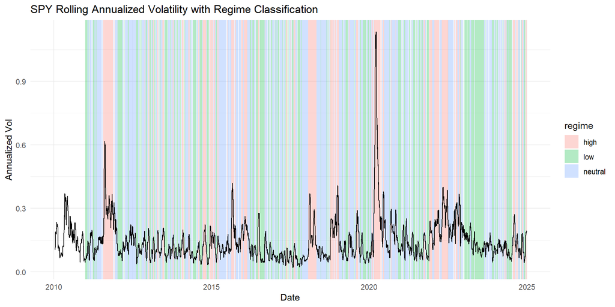

```r
regime_rle <- rle(regime_df_clean$regime)
end_idx <- cumsum(regime_rle$lengths)
start_idx <- c(1, head(end_idx, -1) + 1)

regime_blocks <- data.frame(
  regime = regime_rle$values,
  xmin = regime_df_clean$date[start_idx],
  xmax = regime_df_clean$date[end_idx]
)

ggplot(roll_vol_df) +
  geom_rect(data = regime_blocks,
            aes(xmin = xmin, xmax = xmax,
                ymin = -Inf, ymax = Inf, fill = regime), alpha = 0.3) + geom_line(aes(x = date, y = roll_vol)) + labs(title = "SPY Rolling Annualized Volatility with Regime Classification",x = "Date", y = "Annualized Vol") + theme_minimal()
```

## Entry & Exit Rules

The strategy uses two conditions for entry and a looser OR condition for exit:

-**Entry**: Low vol regime and EMA(10) > EMA(30), a calm market with an upward momentum

-**EXIT**: High vol regime or EMA(10) < EMA(30), either danger signal triggers an exit.

This asymmetric structure of a strict entry and a loose exit is designed to protect capital by getting out quickly when either signal deteriorates.

### Backtesting Function

```r
run_backtest <- function(data) {
  trades <- data.frame(
    entry_date = as.Date(character()),
    exit_date = as.Date(character()),
    direction         = as.character(),
    entry_price       = as.numeric(),
    exit_price        = as.numeric(),
    position_size     = as.numeric(),
    transaction_costs = as.numeric()
  )

  in_position <- FALSE
  entry_date  <- NULL
  entry_price <- NULL

  for (i in 1:nrow(data)) {
    if (!in_position & data$regime[i] == "low" & data$ema_fast[i] > data$ema_slow[i]) {
      entry_date  <- data$date[i]
      entry_price <- data$SPY.Adjusted[i]
      in_position <- TRUE
    } else if (in_position & (data$regime[i] == "high" | data$ema_fast[i]< data$ema_slow[i])) {
      trades <- rbind(trades, data.frame(
        entry_date = entry_date,
        exit_date = data$date[i],
        direction = "long",
        entry_price = entry_price,
        exit_price = data$SPY.Adjusted[i],
        position_size = 1,
        transaction_costs = 0.001

      ))
      in_position <- FALSE
      entry_date  <- NULL
      entry_price <- NULL
    }
  }

  trades |>
    mutate(PnL = (exit_price - entry_price) * position_size - transaction_costs)
}
```

## Results

```r
dates <- inner_join(spy_prices, roll_vol_df, by = "date") |>
  inner_join(regime_df_clean, by = "date")

train <- filter(dates, date < as.Date("2021-01-01"))
test <- filter(dates, date >= as.Date("2021-01-01"))

trades_train <- run_backtest(train)
trades_test  <- run_backtest(test)

summarize_trades <- function(trades, label)
{
  cum_pnl      <- cumsum(trades$PnL)
  running_peak <- cummax(cum_pnl)

  data.frame(
    period = label,
    total_pnl = round(sum(trades$PnL), 2),
    win_rate = round(sum(trades$PnL > 0) / nrow(trades) * 100, 1),
    avg_pnl = round(mean(trades$PnL), 2),
    sharpe = round(mean(trades$PnL) / sd(trades$PnL), 2),
    max_dd = round(min(cum_pnl - running_peak), 2),
    n_trades = nrow(trades)
  )
}

results <- rbind(
  summarize_trades(trades_train, "Train (2010-2020)"), summarize_trades(trades_test, "Test (2021-2024)")
)

knitr::kable(results, caption = "Strategy Performance Summary")
```

Strategy Performance Summary

| period | total_pnl | win_rate | avg_pnl | sharpe | max_dd | n_trades |
| --- | --- | --- | --- | --- | --- | --- |
| Train (2010-2020) | 25.88 | 42.9 | 0.74 | 0.09 | -25.33 | 35 |
| Test (2021-2024) | 135.29 | 63.6 | 12.30 | 0.46 | -19.58 | 11 |

## Limitations & Next Steps

- sample size remains thin: future work will implement walk-forward testing across rolling windows.
- Position sizing is fixed at 1 share: next iteration will implement Kelly Criterion based sizing
- Strategy is Long-only: short signals via momentum reversal to be explored
- Currently limited to SPY: generalization to sector ETFs and individual equities planned.